# Devoir II : Emploi (ACP)

### M1 ISIFAR

**Université Paris Cité**

Academic Year 2023-2024

Project Members : Hengze WANG ; Ruoqi ZHU

[Github Page](https://github.com/Lambpot/Projet_ADD)

```r
to_be_loaded <- c("skimr",
                  "ggplot2",
                  "dplyr",
                  "glue",
                  "DT",
                  "knitr",
                  "unilur",
                  "restatapi",
                  "stats",
                  "factoextra",
                  "corrplot",
                  "dplyr",
                  "tidyr")

for (pck in to_be_loaded) {
  if (!require(pck, character.only = TRUE)) {
    install.packages(pck)
    stopifnot(require(pck, character.only = T))
  }
}
```

[output not shown]

## Importation des données d’Eurostat

```r
#Emploi
emp <- get_eurostat_data("lfsi_emp_a_h",
                                 filters = c("PC_POP","T","Y15-64","EMP_LFS"))
names(emp)[names(emp) == 'values'] <- 'emploi'
emp <- emp %>%
  select(geo, time, emploi)

#Population
pop <- get_eurostat_data("demo_pjan",
                                 filters = c("TOTAL","T"))
names(pop)[names(pop) == 'values'] <- 'population'
pop <- pop %>%
  select(geo, time, population)

#GDP
gdp <- get_eurostat_data("nama_10_gdp",
                                 filters = c("CP_MEUR","B1GQ",""))
names(gdp)[names(gdp) == 'values'] <- 'PIB'
gdp <- gdp %>%
  select(geo, time, PIB)

#Annual net earnings
earn<- get_eurostat_data("earn_nt_net",
                                 filters = c("EUR","TOTAL","P1_NCH_AW100"))
names(earn)[names(earn) == 'values'] <- 'revenu'
earn <- earn %>%
  select(geo, time, revenu)

#Unemployment
unemp <- get_eurostat_data("une_rt_a_h",
                                 filters = c("PC_POP","T","Y15-74"))
names(unemp)[names(unemp) == 'values'] <- 'chomage'
unemp <- unemp %>%
  select(geo, time, chomage)

#Espérance de vie
vie <- get_eurostat_data("demo_mlexpecedu",
                         filters = c("T", "Y_LT1","TOTAL" ))
names(vie)[names(vie) == 'values'] <- 'esperance'
vie <- vie %>%
  select(geo, time, esperance)
```

Nous avons sélectionné six dataframes d’Eurostat, en filtrant chaque dataframe pour les conditions qui répondent à nos besoins et en renommant les noms qui représentent les variables dans ce projet, nous avons obtenu six dataframes qui contiennent uniquement “geo (country), time (year), variable” pour chaque pays européen pour l’année donnée : taux d’emploi, population, PIB, revenus annuels nets, taux de chômage et espérance de vie. Dans notre projet, la variable cible est le taux d’emploi, les cinq facteurs affectant le taux d’emploi sont des variables quantitatives. Nous utiliserons donc ACP pour réduire l’échelle des données et extraire les principales composantes affectant le taux d’emploi.

```r
# Jointure des data ci-dessus
df <- emp %>%
  inner_join(pop, by = c('geo', 'time')) %>%
  inner_join(gdp, by = c('geo', 'time')) %>%
  inner_join(earn, by = c('geo', 'time')) %>%
  inner_join(unemp, by = c('geo', 'time')) %>%
  inner_join(vie, by = c('geo', 'time'))

# Combinaison de geo et time comme individu
df <- unite(df, individu, c(geo, time))
glimpse(df)
```

```
Rows: 151
Columns: 7
$ individu   <chr> "BG_2008", "BG_2009", "BG_2010", "BG_2011", "BG_2012", "BG_…
$ emploi     <dbl> 64.0, 62.6, 59.8, 58.4, 58.8, 59.5, 61.0, 62.9, 63.4, 66.9,…
$ population <dbl> 7518002, 7467119, 7421766, 7369431, 7327224, 7284552, 72456…
$ PIB        <dbl> 37246.7, 37417.7, 38290.0, 41479.9, 42255.3, 42056.2, 43024…
$ revenu     <dbl> 4015.29, 4459.09, 4744.21, 5116.99, 5421.32, 5722.04, 6077.…
$ chomage    <dbl> 3.3, 4.0, 6.0, 6.5, 7.2, 7.7, 6.9, 5.5, 4.5, 3.8, 2.7, 2.6,…
$ esperance  <dbl> 73.3, 73.7, 73.8, 74.2, 74.4, 74.9, 74.5, 74.7, 74.9, 74.8,…
```

```r
skimr :: skim(df) #il n'y a pas de missing value dans notre database
```

Data summary

| Name | df |
| --- | --- |
| Number of rows | 151 |
| Number of columns | 7 |
| _______________________ |  |
| Column type frequency: |  |
| character | 1 |
| numeric | 6 |
| ________________________ |  |
| Group variables | None |

**Variable type: character**

| skim_variable | n_missing | complete_rate | min | max | empty | n_unique | whitespace |
| --- | --- | --- | --- | --- | --- | --- | --- |
| individu | 0 | 1 | 7 | 7 | 0 | 151 | 0 |

**Variable type: numeric**

| skim_variable | n_missing | complete_rate | mean | sd | p0 | p25 | p50 | p75 | p100 | hist |
| --- | --- | --- | --- | --- | --- | --- | --- | --- | --- | --- |
| emploi | 0 | 1 | 63.93 | 7.54 | 46.30 | 58.60 | 63.80 | 69.9 | 78.00 | ▂▆▇▆▅ |
| population | 0 | 1 | 15671664.85 | 20070273.61 | 405616.00 | 5080165.50 | 7327224.00 | 10892412.5 | 79814871.00 | ▇▁▁▁▁ |
| PIB | 0 | 1 | 303889.37 | 410945.24 | 5790.30 | 48100.50 | 179610.80 | 359006.5 | 1736592.80 | ▇▂▁▁▁ |
| revenu | 0 | 1 | 27954.71 | 19993.48 | 4015.29 | 12575.35 | 19658.32 | 47733.1 | 76337.32 | ▇▃▂▃▁ |
| chomage | 0 | 1 | 5.58 | 2.54 | 1.80 | 4.10 | 5.30 | 6.2 | 16.30 | ▇▇▂▁▁ |
| esperance | 0 | 1 | 78.80 | 2.87 | 73.10 | 76.35 | 79.60 | 81.3 | 83.40 | ▅▅▅▇▇ |

```r
# Convertir la colonne individu en clé
rownames(df) <- df$individu
df <- df[, -1]
datatable(df)
```

|  | emploi | population | PIB | revenu | chomage | esperance |
| --- | --- | --- | --- | --- | --- | --- |
| BG_2008 | 64 | 7518002 | 37246.7 | 4015.29 | 3.3 | 73.3 |
| BG_2009 | 62.6 | 7467119 | 37417.7 | 4459.09 | 4 | 73.7 |
| BG_2010 | 59.8 | 7421766 | 38290 | 4744.21 | 6 | 73.8 |
| BG_2011 | 58.4 | 7369431 | 41479.9 | 5116.99 | 6.5 | 74.2 |
| BG_2012 | 58.8 | 7327224 | 42255.3 | 5421.32 | 7.2 | 74.4 |
| BG_2013 | 59.5 | 7284552 | 42056.2 | 5722.04 | 7.7 | 74.9 |
| BG_2014 | 61 | 7245677 | 43024.7 | 6077.09 | 6.9 | 74.5 |
| BG_2015 | 62.9 | 7202198 | 45797.8 | 6537.22 | 5.5 | 74.7 |
| BG_2016 | 63.4 | 7153784 | 48752.1 | 7064.38 | 4.5 | 74.9 |
| BG_2017 | 66.9 | 7101859 | 52501.8 | 7808.94 | 3.8 | 74.8 |

[output cut: 141 more lines]

Nous avons obtenu un jeu de données avec le pays et la date comme clés. Pour chaque individu, nous disposons d’une collection de variables quantitatives.

## Descriptive statistique

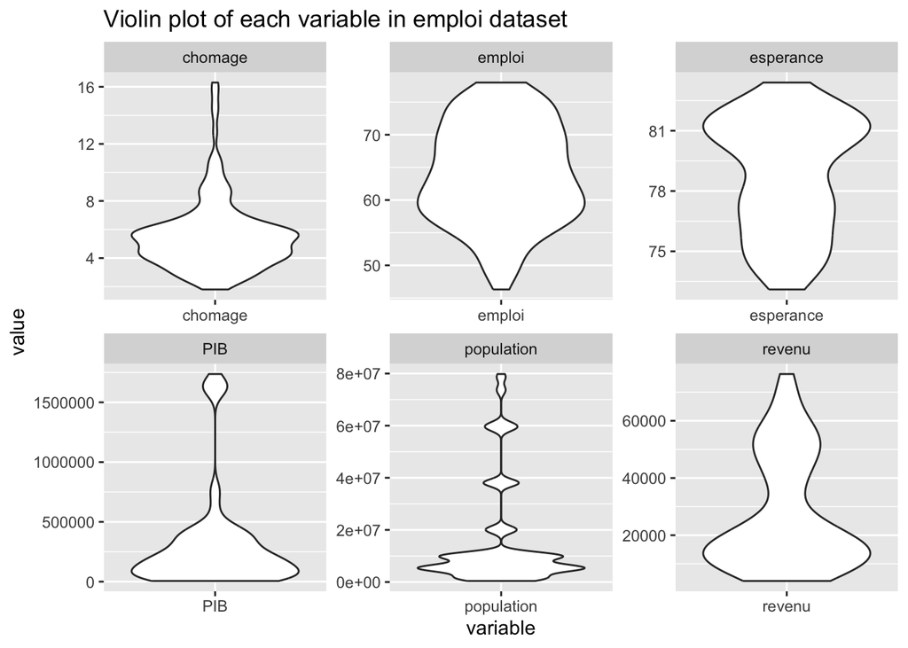

```r
df %>%
  pivot_longer(cols = everything(),
               values_to = "value",         ## première colonne
               names_to = "variable") %>%   ## deuxième colonne
  ggplot(aes(y=value, x=variable)) +
  geom_violin() +
  facet_wrap(~variable, scales = "free") +
  labs(title = "Violin plot of each variable in emploi dataset")
```

## Correlation

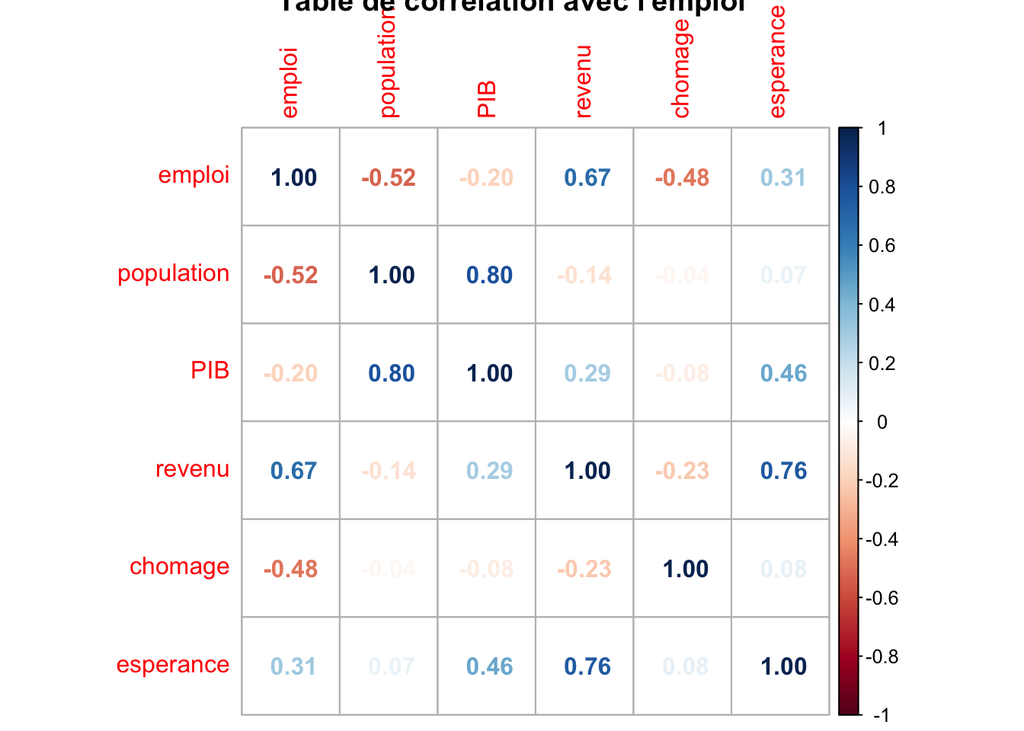

```r
df %>%
  cor() %>%
  corrplot::corrplot(method = "number",
                     title = "Table de corrélation avec l'emploi")
```

La variable “emploi” montre une forte corrélation positive avec “revenu” (0,67), ce qui suggère que l’emploi tend à augmenter avec le revenu.

Il existe également une corrélation négative modérée entre “emploi” et “chomage” (-0,48), indiquant que des taux de chômage plus élevés sont généralement associés à des taux d’emploi plus faibles, ce qui est cohérent avec la logique économique.

La variable “population” a une forte corrélation positive avec “PIB” (0,80), ce qui pourrait indiquer que les économies avec une population plus importante ont tendance à avoir un PIB plus élevé.

On observe aussi que “esperance” a une corrélation relativement élevée avec “revenu” (0,76), ce qui pourrait impliquer que des revenus plus élevés sont associés à une espérance de vie plus longue, peut-être en raison de meilleures conditions de vie et d’accès aux soins de santé.

La variable “PIB” a une corrélation négative faible avec “emploi” (-0,20), ce qui est un peu surprenant car on pourrait s’attendre à une corrélation positive. Cela pourrait nécessiter une enquête plus approfondie pour comprendre la dynamique sous-jacente entre ces variables.

## Réalisation de l’ACP sur les covariables

```r
df_x <- df %>%
  select(-emploi)  ## on selectionne toutes les vars sauf emploi, parce que emploi est y;
df_pca_standard <- df_x %>%
  prcomp(center = TRUE, scale. = TRUE)  ## centrer chaque colonne; diviser par écart-type de chaque colonne => (xi-xi_bar)/sigmai_chapeau;
summary(df_pca_standard) ## on fait l'ACP jusqu'à PC3 pour avoir 90% culumative proportion;
```

```
Importance of components:
                          PC1    PC2    PC3     PC4     PC5
Standard deviation     1.4785 1.2303 1.0230 0.39589 0.31182
Proportion of Variance 0.4372 0.3027 0.2093 0.03135 0.01945
Cumulative Proportion  0.4372 0.7399 0.9492 0.98055 1.00000
```

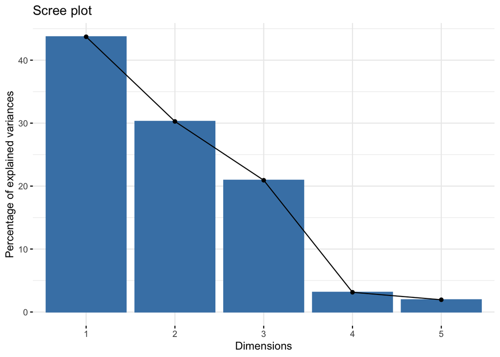

```r
## Scree plot
fviz_eig(df_pca_standard)
```

L’importance des composantes est mesurée par la déviation standard de chaque composante principale (PC), avec la proportion de la variance qu’elle explique et la proportion cumulative de la variance.

- La première composante principale (PC1) présente une déviation standard de 1.4785 et explique 43.72% de la variance totale des données.
- La deuxième composante principale (PC2) a une déviation standard de 1.2303 et explique 30.27% de la variance supplémentaire.
- La trois composante principale (PC3) a une déviation standard de 1.0230 et explique 20.93% de la variance supplémentaire, portant la proportion cumulative de la variance expliquée à 94.92%.
- Les troisième, quatrième et cinquième composantes principales (PC4 et PC5) ajoutent progressivement moins de variance expliquée, avec une contribution cumulative qui atteint 100% sur les cinq composantes.

Le Scree plot illustre la proportion de la variance expliquée par chaque composante principale. Ce graphique est souvent utilisé pour déterminer le nombre de composantes à retenir selon le critère du coude (elbow criterion).

l’ACP a réussi à réduire la dimensionnalité de l’ensemble de données tout en conservant une grande partie de l’information originale

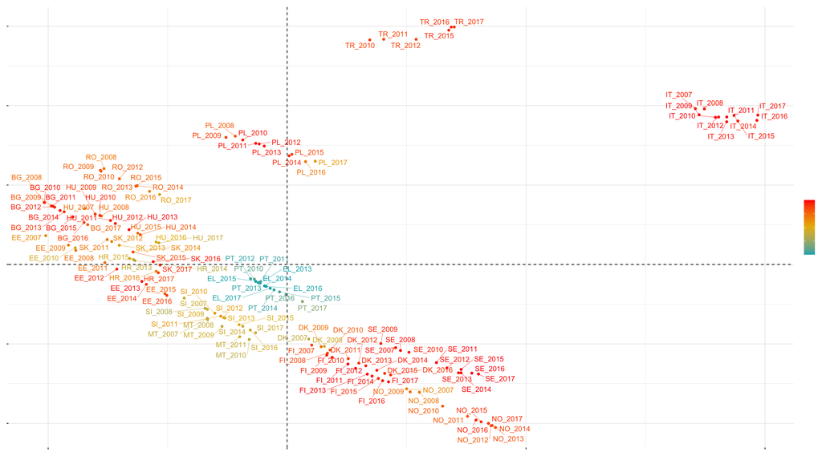

```r
## Biplot
pca_plot <- fviz_pca_ind(df_pca_standard,
             col.ind = "cos2",
             gradient.cols = c("#00AFBB", "#E7B800", "red"),
             repel = TRUE,
             title = "Biplot des individus")
pca_plot <- pca_plot + theme(text = element_text(size = 0.1))
pca_plot
```

- **Répartition des Points** : Les points sont répartis sur tout le graphique, ce qui suggère une grande variabilité entre les individus à travers les deux composantes principales.
- **Densité et Couleur** : Les zones avec une densité élevée de points pourraient indiquer des individus ayant des profils similaires. Les points colorés en rouge représentent ceux pour lesquels la projection sur les composantes principales est la plus représentative.
- **Regroupements et Isolation** : Certains groupes de points semblent se regrouper (comme ceux qui pourraient représenter un pays à différentes années), tandis que d’autres points sont plus isolés, ce qui pourrait indiquer des caractéristiques uniques ou des changements significatifs pour ces individus au fil du temps.
- **Interprétation des Axes** : Sans connaître la signification exacte des composantes principales (PC1 et PC2), il est difficile de donner une interprétation précise. Néanmoins, les points qui sont proches sur l’axe horizontal (PC1) ont des caractéristiques similaires qui sont fortement influencées par les variables qui chargent principalement sur cette composante.

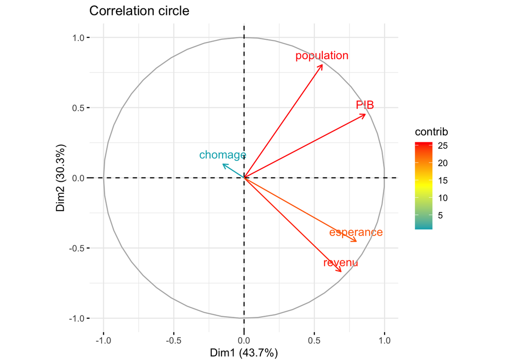

```r
# Projections des variables de visualisation sur les première et deuxième composantes principales de l'ACP
fviz_pca_var(df_pca_standard, col.var = "contrib",
             gradient.cols = c("#00AFBB", "yellow", "red"),
             title = "Correlation circle")
```

- **Axes des Composantes Principales** : L’axe horizontal (Dim1) représente la première composante principale et explique 43.7% de la variance, tandis que l’axe vertical (Dim2) représente la deuxième composante principale et explique 30.3% de la variance.
- **Position des Variables** : Les variables sont représentées par des vecteurs, et leur position par rapport aux axes indique leur corrélation avec les composantes principales. Plus un vecteur est proche d’un axe, plus la variable correspondante est fortement corrélée avec cette composante principale.
- **Corrélation entre les Variables** : Les variables qui pointent dans la même direction générale sont positivement corrélées, tandis que celles qui pointent dans des directions opposées sont négativement corrélées. Par exemple, “PIB” et “population” sont positivement corrélées, ce qui suggère que des valeurs plus élevées pour l’une sont associées à des valeurs plus élevées pour l’autre dans les données.
- **Contribution des Variables** : La couleur des vecteurs indique leur contribution à la composante principale respective, avec des couleurs plus chaudes (comme le rouge) indiquant une contribution plus élevée. “PIB”, “population” et “revenue” semblent être des contributeurs importants à la première composante principale.

```r
## Scores des PC
pca_scores <- df_pca_standard$x
datatable(pca_scores)
```

|  | PC1 | PC2 | PC3 | PC4 | PC5 |
| --- | --- | --- | --- | --- | --- |
| BG_2008 | -2.033837072027837 | 0.7815201389705964 | 1.273379492857345 | -0.2347084820130111 | 0.2909226126153703 |
| BG_2009 | -1.976805332876493 | 0.7383779473558761 | 0.9734818759102516 | -0.2223467806406308 | 0.2699179554221288 |
| BG_2010 | -2.030740064002623 | 0.7794038633228138 | 0.2132662542162208 | -0.4116488852031355 | 0.2412885151015105 |
| BG_2011 | -1.963131075378854 | 0.7346102171445715 | -0.01177366273448951 | -0.3780885498479878 | 0.2290231231588534 |
| BG_2012 | -1.94599380790401 | 0.7217759039638448 | -0.292943330061245 | -0.4106206247765516 | 0.2145789316926775 |
| BG_2013 | -1.865859726130664 | 0.6633765303851774 | -0.5279365199445131 | -0.3486160894861766 | 0.1953719035360161 |
| BG_2014 | -1.900333355622598 | 0.6797983457293013 | -0.1871311781504929 | -0.3766086763834287 | 0.2110962654368424 |
| BG_2015 | -1.792959957475985 | 0.5990440004892607 | 0.3216761426829805 | -0.2004779283653292 | 0.2247310240028558 |
| BG_2016 | -1.699819176346781 | 0.5289336228178213 | 0.6804224411473171 | -0.0674243272709514 | 0.2327558067471641 |
| BG_2017 | -1.669007083344936 | 0.5014079443185375 | 0.9563281554735964 | -0.04578935639205621 | 0.2410331383225401 |

[output cut: 141 more lines]

Ces scores indiquent les coordonnées des données originales dans le nouvel espace des composantes principales et peuvent être utilisés pour d’autres analyses telles que le data clustering.

## Conclusion

Dans cette analyse de données, nous avons exploré un ensemble de données comprenant des informations sur l’emploi, la population, le PIB, les revenus, le chômage et l’espérance de vie dans différents pays et années. Voici les principales conclusions tirées de cette analyse :

1. **Distribution des Variables** : Nous avons examiné la distribution de chaque variable et noté des caractéristiques intéressantes. Par exemple, la distribution de l’emploi était relativement uniforme, tandis que le chômage présentait un pic marqué.
2. **Corrélation entre les Variables** : Nous avons calculé la matrice de corrélation entre les variables et noté des relations importantes. Par exemple, il existe une forte corrélation positive entre l’emploi et le revenu, tandis que le chômage est négativement corrélé avec l’emploi, ce qui est cohérent avec la théorie économique.
3. **Analyse en Composantes Principales (ACP)** : Nous avons effectué une ACP pour réduire la dimensionnalité de l’ensemble de données. Les deux premières composantes principales expliquent ensemble plus de 74% de la variance totale des données, ce qui suggère qu’elles capturent efficacement l’essentiel de l’information.
4. **Interprétation de l’ACP** : Nous avons interprété les résultats de l’ACP en examinant les biplots des individus et des variables. Les biplots ont montré comment les individus et les variables sont liés aux composantes principales. Par exemple, certains pays ont été identifiés comme ayant des profils distincts en fonction des scores des composantes principales.

En conclusion, cette analyse de données a permis de mettre en évidence des relations intéressantes entre différentes variables liées à l’économie et à la démographie des pays. L’ACP a été particulièrement utile pour réduire la dimensionnalité des données tout en préservant l’information essentielle. Ces résultats pourraient servir de base à des analyses plus approfondies ou à des études comparatives entre les pays.